# Explore more realistic dosing scenarios

Andy Stein

25 April, 2018

```r
suppressMessages(source("ams_initialize_script.R"))
```

### Set initial parameters and functions

Here use doses ranging from 0.1-100 mg/kg or 47-4.710^{4} nmol because this is a more realistic dose range to consider.

```r
dose.nmol.range = lseq(.1,100,7)*scale.mpk2nmol

model = ivsc_4cmtct_shedct()

tmax = 26*7 #days
tau  = 21   #days
compartment = 2
```

### Function for comparing theory and simulation

```r
compare.theory.sim = function(model=model, param.as.double=param.as.double,
                          dose.nmol.range = dose.nmol.range,
                          tmax=tmax,tau=tau,dt=dt,compartment=compartment) {

  df_sim = data.frame() # put all simulations for different dose into one data frame
  for (dose.nmol in dose.nmol.range){
    row = lumped.parameters.simulation(model,
      param.as.double, dose.nmol, tmax, tau, compartment)
    df_sim = rbind(df_sim, row)
  }
  df_sim$Dose = dose.nmol.range

  df_thy = data.frame() # put all theoretical calculations of lumped parameters at different dose together
  for (dose.nmol in dose.nmol.range){
    row = lumped.parameters.theory(param.as.double=param.as.double,
                                   dose.nmol=dose.nmol,
                                   tau=tau)
    df_thy = rbind(df_thy, row)
  }
  df_thy = df_thy %>%
    mutate(Dose = dose.nmol.range,
           AFIRT = AFIRT.Kssd,
           TFIRT = TFIRT.Kssd)

  df_compare = bind_rows(df_thy,df_sim)
  df_compare = df_compare %>%
    arrange(Dose,type) %>%
    mutate_if(is.numeric,signif,2)


  #do a single simulation to make sure model is at steady state
  out = simulation(model=model, param.as.double=param.as.double,
        dose.nmol=max(dose.nmol.range), tmax=tmax, tau=tau) %>%
    select(time,D1,D3,M3,DM3,Mfree.pct) %>%
    gather(cmt,value,-c(time))

  g = ggplot(out,aes(x=time,y=value,group=cmt,color=cmt))
  g = g + geom_line()
  g = g + scale.y.log10()
  g = xscale("w27",increment = 3)
  print(g)

  #plot theory vs simulation
  df_plot = df_compare %>%
    select(-contains("AFIRT"),AFIRT) %>%
    gather(param,value,-c(type,Dose))


  g = ggplot(df_plot, aes(Dose, value, group=type, color=type,linetype=type))
  g = g + scale.x.log10()
  g = g + scale.y.log10()
  g = g + geom_line()
  g = g + geom_point()
  g = g + facet_wrap(~param,scales = "free_y")
  print(g)

  return(df_compare)
}
```

### Herceptin

Because the receptor density of Herceptin is high, it make sense you need much higher doses to get good agreement. In the clinic, Herceptin is dosed at only 6 mg/kg or 2800 nmol.

What I believe is happening then is all the drug in the tumor (Cavg3) is getting sucked into the tumor and thus intratumoral concentrations are lower than the theory predicts.

It would mkae sense to check this against other Herceptin modeling papers to see if they agree that there isn’t saturation around 6 mg/kg. Could check in with Greg Thurber at some point.

```r
param.as.double =  read.param.file("../data/ModelF_Herceptin_Params.xlsx")
p.herceptin     =  as.data.frame(t(param.as.double))
df_compare = compare.theory.sim(model = model,
                                param.as.double = param.as.double,
                                dose.nmol.range = dose.nmol.range,
                                tmax = tmax,
                                tau  = tau,
                                compartment = compartment)
```

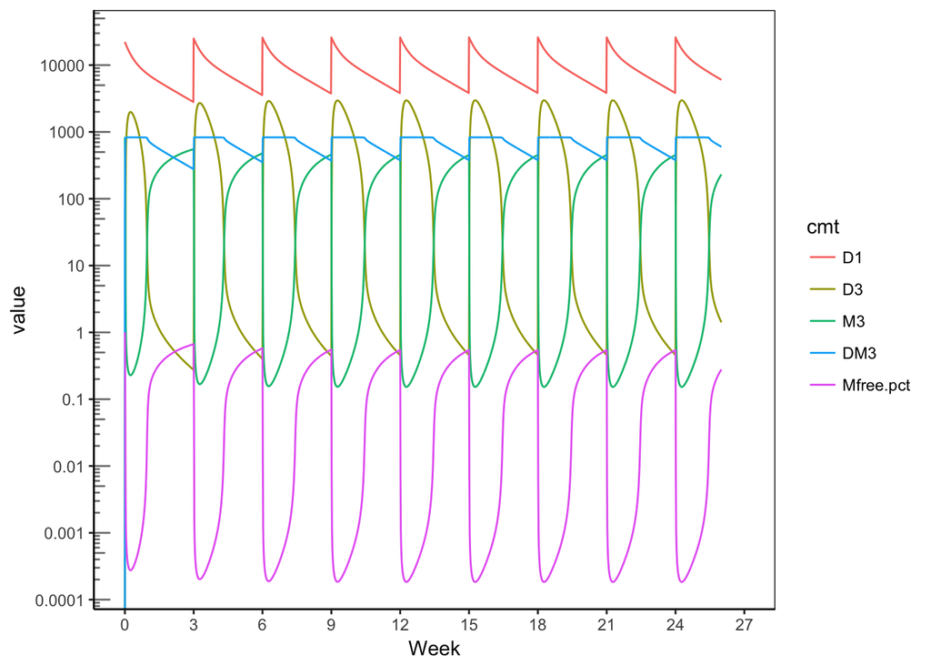

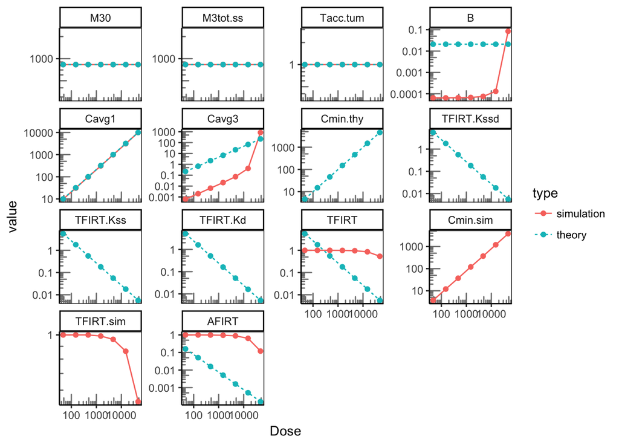

### Atezolizumab

Atezolizumab is dosed at 1200 mg or 8000 nmol. Andy doesn’t currently know the kon and koff rates for atezolizumab. He guessed koff = 3/d, but it could be 10 faster.

```r
param.as.double = read.param.file("../data/ModelF_Atezolizumab_Params.xlsx")
p.atezo         = as.data.frame(t(param.as.double))
df_compare = compare.theory.sim(model = model,
                                param.as.double = param.as.double,
                                dose.nmol.range = dose.nmol.range,
                                tmax = tmax,
                                tau  = tau,
                                compartment = compartment)
```

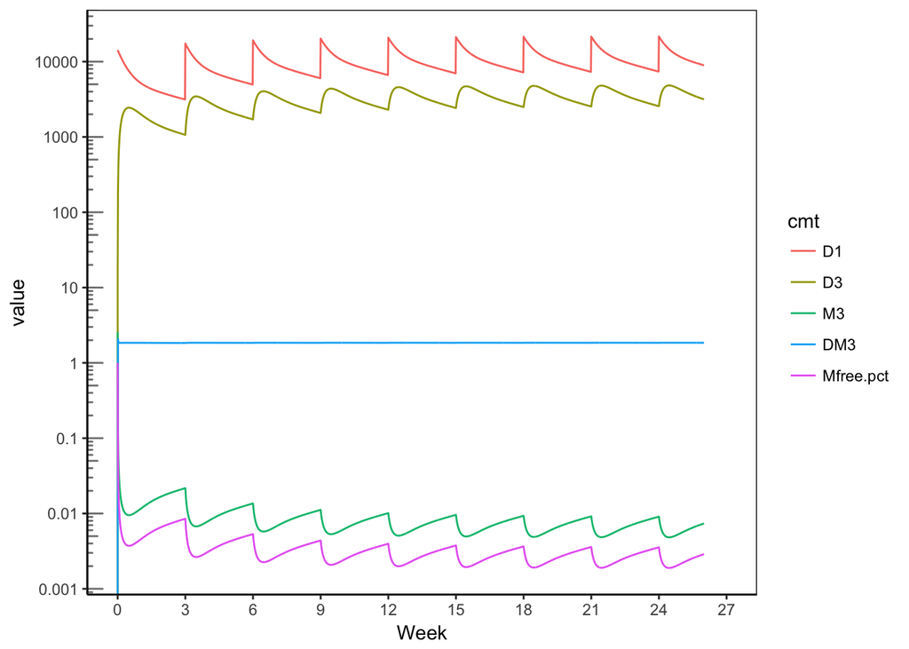

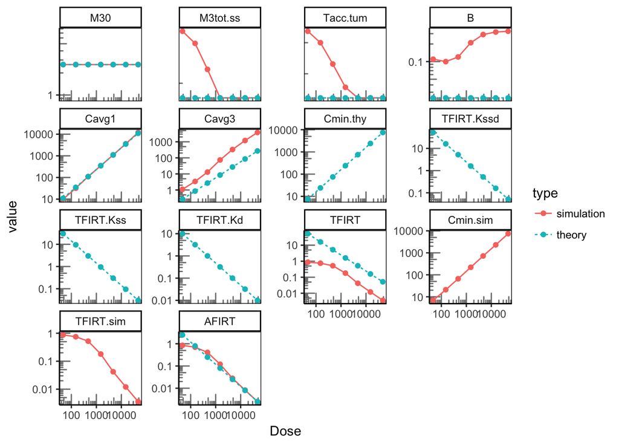

### Pembrolizumab

Pembrolizumab is often doset at 200 mg or 1333.3333333 nmol. Because PD-1 target expression is lower than atezolizumab, the theory is in agreement even at the smaller doses (unlike Atezo)

```r
param.as.double = read.param.file("../data/ModelF_Pembrolizumab_Params.xlsx")
p.pembro        = as.data.frame(t(param.as.double))
df_compare = compare.theory.sim(model = model,
                                param.as.double = param.as.double,
                                dose.nmol.range = dose.nmol.range,
                                tmax = tmax,
                                tau  = tau,
                                compartment = compartment)
```

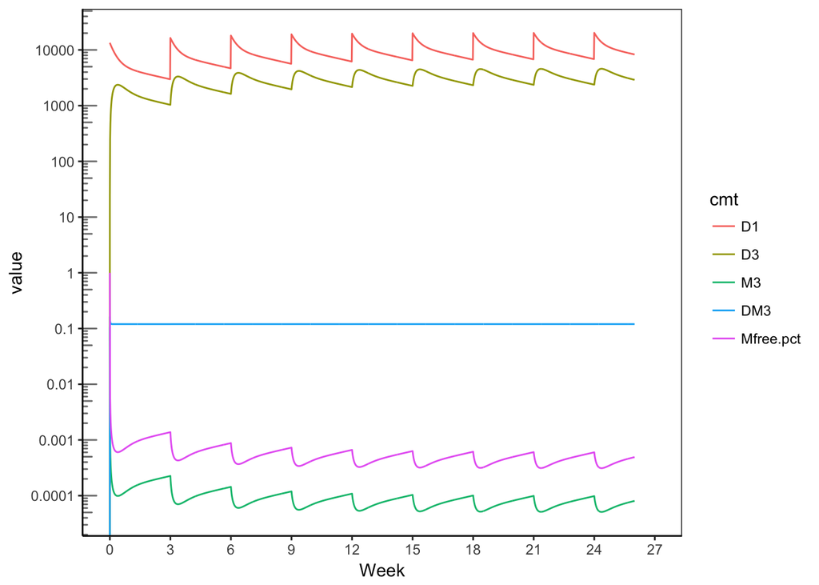

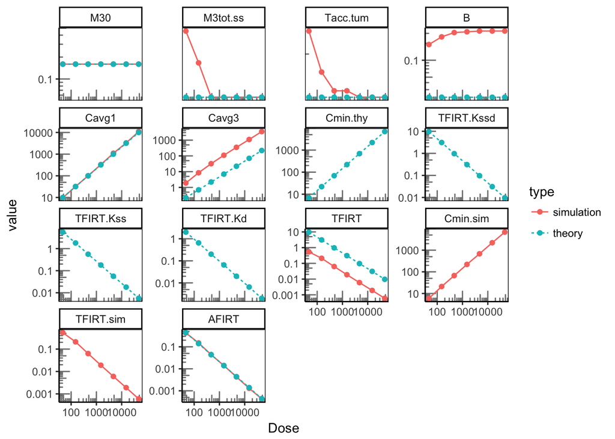